# Análisis Exploratorio Multivariado

Matrices de covarianza, correlación, distancias · Semanas 2-3

Juan Sebastián Guayazán · Esteban Valente · Diego Nocua

20 de noviembre de 2026

**En resumen.** Exploración previa a los métodos multivariados: tipos de variables, medias, covarianzas y correlaciones, boxplots (clásicos y ajustados), matriz de dispersión y distancias (euclídea, estandarizada y de Mahalanobis). Es un análisis independiente de la cadena 1.070 → 970 del PCA.

> **Semanas 2–3 del programa:** matriz de datos, tipos de variables, preparación, escalamiento, estandarización y visualización exploratoria. Se estudian medidas de localización y dispersión multivariada mediante medias, covarianzas, correlaciones, varianza total y varianza generalizada.

## Cómo leer este informe

Este documento tiene dos niveles que deben distinguirse:

- **Análisis principal:** trabaja con 11 variables continuas para calcular estadísticos, visualizaciones, distancias y diagnósticos multivariados.
- **Anexo complementario:** presenta gráficos exploratorios de las 14 variables cuantitativas originales. Es una ampliación visual y no cambia la matriz de 11 variables usada en los cálculos principales.

La base se filtra por altitud y por registros completos en las 14 variables seleccionadas. El tamaño de muestra resultante se imprime durante la ejecución del primer bloque.

**Pregunta que responde:** ¿cómo se distribuyen las variables, qué relaciones presentan y qué aspectos conviene considerar antes de aplicar métodos multivariados?

La preparación específica que lleva a la matriz del PCA se documenta por separado en 01-pca/depuracion.Rmd.

# 1. Carga y preparación de datos

Se leen los datos limpios de café Arábica y se seleccionan 14 variables cuantitativas. El código conserva los registros cuya altitud está entre 0 y 3.000 metros (sin incluir valores faltantes) y elimina filas incompletas en cualquiera de las 14 variables seleccionadas.

Después de preparar la tabla, se definen dos conjuntos para el análisis:

- 11 variables continuas para los cálculos multivariados principales.
- 3 variables con inflación de ceros —humedad y defectos de categorías 1 y 2— que se describen por separado en el código.

Este filtro pertenece al EDA y no debe confundirse con la secuencia de depuración posterior del PCA.

```r
library(dplyr)
library(ggplot2)
library(GGally)      # ggpairs
library(corrplot)    # corrplot
library(robustbase)  # adjboxStats, mc

data_raw <- read.csv("../data/arabica_data_cleaned.csv")

vars_originales <- c("Aroma","Flavor","Aftertaste","Acidity","Body","Balance",
                     "Uniformity","Clean.Cup","Sweetness","Cupper.Points",
                     "Moisture","Category.One.Defects","Category.Two.Defects",
                     "altitude_mean_meters")

datos <- data_raw %>%
  filter(!is.na(altitude_mean_meters),
         altitude_mean_meters > 0,
         altitude_mean_meters <= 3000) %>%
  select(all_of(vars_originales)) %>%
  filter(complete.cases(.)) %>%
  rename(
    Sabor=Flavor, Retrogusto=Aftertaste, Acidez=Acidity, Cuerpo=Body,
    Uniformidad=Uniformity, Taza.Limpia=Clean.Cup, Dulzura=Sweetness,
    Puntaje.Catador=Cupper.Points, Humedad=Moisture,
    Defectos.Cat1=Category.One.Defects, Defectos.Cat2=Category.Two.Defects,
    Altitud=altitude_mean_meters
  )

cat("Dimensiones:", nrow(datos), "lotes ×", ncol(datos), "variables\n")
```

```
## Dimensiones: 1070 lotes × 14 variables
```

```r
glimpse(datos)
```

```
## Rows: 1,070
## Columns: 14
## $ Aroma           <dbl> 8.67, 8.75, 8.42, 8.17, 8.25, 8.25, 8.67, 8.08, 8.17, …
## $ Sabor           <dbl> 8.83, 8.67, 8.50, 8.58, 8.50, 8.33, 8.67, 8.58, 8.67, …
## $ Retrogusto      <dbl> 8.67, 8.50, 8.42, 8.42, 8.25, 8.50, 8.58, 8.50, 8.25, …
## $ Acidez          <dbl> 8.75, 8.58, 8.42, 8.42, 8.50, 8.42, 8.42, 8.50, 8.50, …
## $ Cuerpo          <dbl> 8.50, 8.42, 8.33, 8.50, 8.42, 8.33, 8.33, 7.67, 7.75, …
## $ Balance         <dbl> 8.42, 8.42, 8.42, 8.25, 8.33, 8.50, 8.42, 8.42, 8.17, …
## $ Uniformidad     <dbl> 10.00, 10.00, 10.00, 10.00, 10.00, 10.00, 9.33, 10.00,…
## $ Taza.Limpia     <dbl> 10, 10, 10, 10, 10, 10, 10, 10, 10, 10, 10, 10, 10, 10…
## $ Dulzura         <dbl> 10.00, 10.00, 10.00, 10.00, 10.00, 9.33, 9.33, 10.00, …
## $ Puntaje.Catador <dbl> 8.75, 8.58, 9.25, 8.67, 8.58, 9.00, 8.67, 8.50, 8.58, …
## $ Humedad         <dbl> 0.12, 0.12, 0.00, 0.11, 0.12, 0.03, 0.03, 0.10, 0.10, …
## $ Defectos.Cat1   <int> 0, 0, 0, 0, 0, 0, 0, 0, 0, 0, 0, 0, 0, 0, 0, 0, 0, 0, …
## $ Defectos.Cat2   <int> 0, 1, 0, 2, 2, 0, 0, 4, 1, 0, 0, 2, 2, 0, 0, 0, 8, 0, …
## $ Altitud         <dbl> 2075.0, 2075.0, 1700.0, 2000.0, 2075.0, 1635.0, 1635.0…
```

## 1.1. Tipos de variables

```r
# Variables numéricas continuas (cuantitativas)
vars_continuas <- c("Aroma","Sabor","Retrogusto","Acidez","Cuerpo","Balance",
                    "Uniformidad","Taza.Limpia","Dulzura","Puntaje.Catador","Altitud")

# Variables con inflación de ceros (problemáticas)
vars_infladas <- c("Humedad","Defectos.Cat1","Defectos.Cat2")

cat("Variables continuas (11):\n"); cat(vars_continuas, sep=", "); cat("\n")
```

```
## Variables continuas (11):
```

```
## Aroma, Sabor, Retrogusto, Acidez, Cuerpo, Balance, Uniformidad, Taza.Limpia, Dulzura, Puntaje.Catador, Altitud
```

```r
cat("\nVariables con inflación de ceros (3):\n"); cat(vars_infladas, sep=", "); cat("\n")
```

```
##
## Variables con inflación de ceros (3):
```

```
## Humedad, Defectos.Cat1, Defectos.Cat2
```

# 2. Estadísticos de localización y dispersión multivariada

Los estadísticos de esta sección se calculan sobre las 11 variables continuas definidas en el código. Permiten describir el centro, la variabilidad individual y la relación lineal entre variables. Como las variables están en escalas distintas, las covarianzas y la traza dependen de las unidades originales; la matriz de correlaciones facilita comparar la intensidad y dirección de las asociaciones lineales.

## 2.1. Vector de medias

```r
mu <- colMeans(datos[, vars_continuas])
round(mu, 3)
```

```
##           Aroma           Sabor      Retrogusto          Acidez          Cuerpo
##           7.570           7.518           7.391           7.527           7.505
##         Balance     Uniformidad     Taza.Limpia         Dulzura Puntaje.Catador
##           7.507           9.866           9.847           9.923           7.485
##         Altitud
##        1304.479
```

**Cómo se lee.** Los siete puntajes sensoriales principales promedian entre 7,39 y 7,57 (en una escala de 0 a 10): casi todos los lotes puntúan alto. La altitud promedia 1.304 m, una escala completamente distinta, lo que anticipa la necesidad de estandarizar.

## 2.2. Matriz de varianzas y covarianzas (S)

La diagonal de S contiene las varianzas de cada variable y los elementos fuera de la diagonal contienen las covarianzas por pares. La traza suma las varianzas individuales; el determinante se presenta como medida de variación generalizada de la matriz.

```r
S <- cov(datos[, vars_continuas])
round(S, 3)
```

```
##                  Aroma  Sabor Retrogusto Acidez Cuerpo Balance Uniformidad
## Aroma            0.149  0.130      0.125  0.112  0.103   0.119       0.087
## Sabor            0.130  0.164      0.148  0.132  0.117   0.138       0.099
## Retrogusto       0.125  0.148      0.167  0.127  0.118   0.141       0.101
## Acidez           0.112  0.132      0.127  0.150  0.108   0.122       0.093
## Cuerpo           0.103  0.117      0.118  0.108  0.131   0.121       0.084
## Balance          0.119  0.138      0.141  0.122  0.121   0.174       0.102
## Uniformidad      0.087  0.099      0.101  0.093  0.084   0.102       0.280
## Taza.Limpia      0.116  0.143      0.145  0.108  0.099   0.138       0.209
## Dulzura          0.081  0.092      0.092  0.082  0.078   0.090       0.156
## Puntaje.Catador  0.132  0.158      0.158  0.135  0.126   0.154       0.103
## Altitud         27.221 26.466     26.272 32.355 18.316  28.238       9.139
##                 Taza.Limpia Dulzura Puntaje.Catador    Altitud
## Aroma                 0.116   0.081           0.132     27.221
## Sabor                 0.143   0.092           0.158     26.466
## Retrogusto            0.145   0.092           0.158     26.272
## Acidez                0.108   0.082           0.135     32.355
## Cuerpo                0.099   0.078           0.126     18.316
## Balance               0.138   0.090           0.154     28.238
## Uniformidad           0.209   0.156           0.103      9.139
## Taza.Limpia           0.634   0.224           0.154     15.238
## Dulzura               0.224   0.263           0.092      2.059
## Puntaje.Catador       0.154   0.092           0.223     29.430
## Altitud              15.238   2.059          29.430 174656.107
```

```r
cat("\nVarianza total (traza de S):", round(sum(diag(S)), 2), "\n")
```

```
##
## Varianza total (traza de S): 174658.4
```

```r
cat("Varianza generalizada (det S):", formatC(det(S), format="e", digits=3), "\n")
```

```
## Varianza generalizada (det S): 2.117e-06
```

**Cómo se lee.** La varianza de la altitud (174.656) representa el 100,00 % de la varianza total, mientras que cada puntaje sensorial varía unas décimas. La varianza total depende de las unidades: por eso un análisis sobre estas escalas lo dominaría la altitud, y por eso se usa la matriz de correlaciones.

## 2.3. Matriz de correlaciones (R)

La correlación estandariza la asociación lineal entre cada par de variables, por lo que sus valores están entre −1 y 1. El mapa de calor ordena las variables jerárquicamente para facilitar la lectura de patrones; la correlación no implica causalidad.

```r
R <- cor(datos[, vars_continuas])
round(R, 3)
```

```
##                 Aroma Sabor Retrogusto Acidez Cuerpo Balance Uniformidad
## Aroma           1.000 0.832      0.790  0.751  0.734   0.739       0.426
## Sabor           0.832 1.000      0.897  0.840  0.800   0.820       0.462
## Retrogusto      0.790 0.897      1.000  0.801  0.799   0.830       0.469
## Acidez          0.751 0.840      0.801  1.000  0.771   0.753       0.453
## Cuerpo          0.734 0.800      0.799  0.771  1.000   0.805       0.438
## Balance         0.739 0.820      0.830  0.753  0.805   1.000       0.464
## Uniformidad     0.426 0.462      0.469  0.453  0.438   0.464       1.000
## Taza.Limpia     0.376 0.443      0.447  0.350  0.343   0.416       0.495
## Dulzura         0.407 0.444      0.439  0.410  0.418   0.419       0.577
## Puntaje.Catador 0.721 0.826      0.821  0.738  0.733   0.782       0.413
## Altitud         0.169 0.156      0.154  0.200  0.121   0.162       0.041
##                 Taza.Limpia Dulzura Puntaje.Catador Altitud
## Aroma                 0.376   0.407           0.721   0.169
## Sabor                 0.443   0.444           0.826   0.156
## Retrogusto            0.447   0.439           0.821   0.154
## Acidez                0.350   0.410           0.738   0.200
## Cuerpo                0.343   0.418           0.733   0.121
## Balance               0.416   0.419           0.782   0.162
## Uniformidad           0.495   0.577           0.413   0.041
## Taza.Limpia           1.000   0.549           0.409   0.046
## Dulzura               0.549   1.000           0.380   0.010
## Puntaje.Catador       0.409   0.380           1.000   0.149
## Altitud               0.046   0.010           0.149   1.000
```

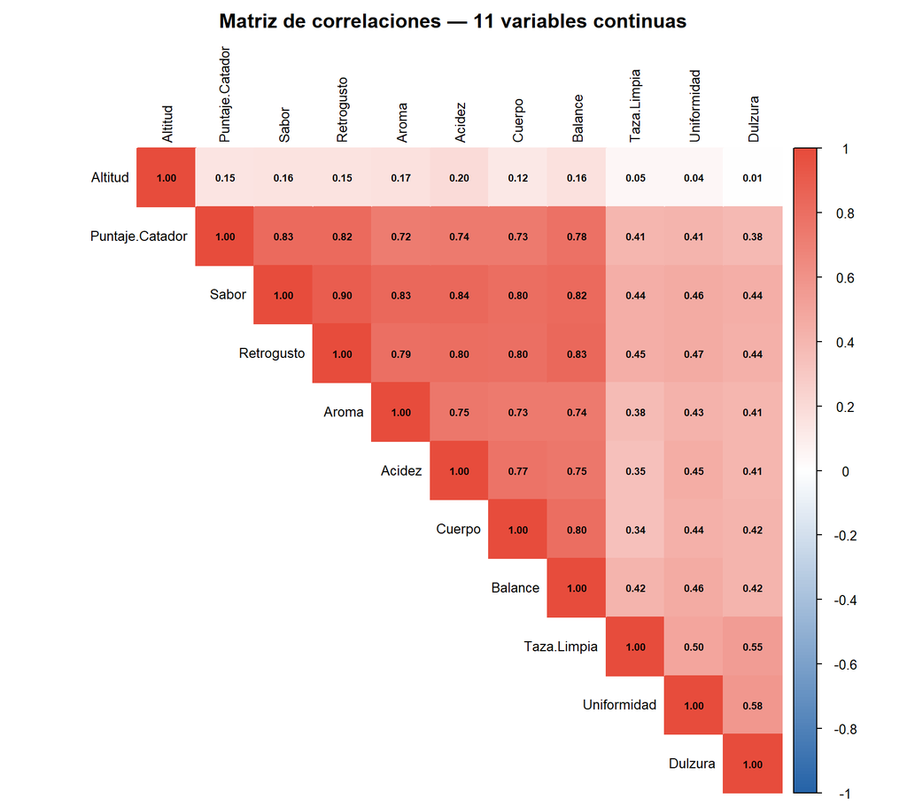

```r
corrplot(R, method="color", type="upper", order="hclust",
         tl.cex=0.8, tl.col="black", addCoef.col="black",
         number.cex=0.6, col=colorRampPalette(c("#2563a8","white","#e74c3c"))(200),
         title="Matriz de correlaciones — 11 variables continuas",
         mar=c(0,0,2,0))
```

**Cómo se lee.** Los puntajes sensoriales (Aroma, Sabor, Retrogusto, Acidez, Cuerpo, Balance y Puntaje del catador) están correlacionados positivamente entre sí, con valores de 0,72 a 0,90: un lote bueno en una dimensión tiende a serlo en las demás. La correlación más alta de todo el conjunto es 0,90 (Sabor y Retrogusto) y la más baja es 0,01 (Dulzura y Altitud). Esta redundancia es lo que hace útil resumir con componentes principales. Correlación no implica causalidad.

## 2.4. Varianza generalizada y varianza total

Esta subsección vuelve a presentar la traza, el determinante y la varianza media para resumir la dispersión conjunta de las 11 variables.

```r
cat("Varianza total       (traza S):", round(sum(diag(S)), 2), "\n")
```

```
## Varianza total       (traza S): 174658.4
```

```r
cat("Varianza generalizada (det S): ", formatC(det(S), format="e", digits=3), "\n")
```

```
## Varianza generalizada (det S):  2.117e-06
```

```r
cat("Varianza media                :", round(sum(diag(S))/ncol(S), 4), "\n")
```

```
## Varianza media                : 15878.04
```

**Cómo se lee.** La varianza generalizada (det S) es un número muy pequeño: indica que, por la fuerte correlación entre variables, los datos ocupan un «volumen» reducido en el espacio de 11 dimensiones. Es otra señal de redundancia entre variables.

# 3. Visualización exploratoria

Las gráficas permiten observar forma, dispersión, asimetrías y posibles valores extremos. Cada variable conserva su escala original en los boxplots principales, por lo que las magnitudes no son directamente comparables entre variables con unidades distintas.

## 3.1. Boxplots univariados

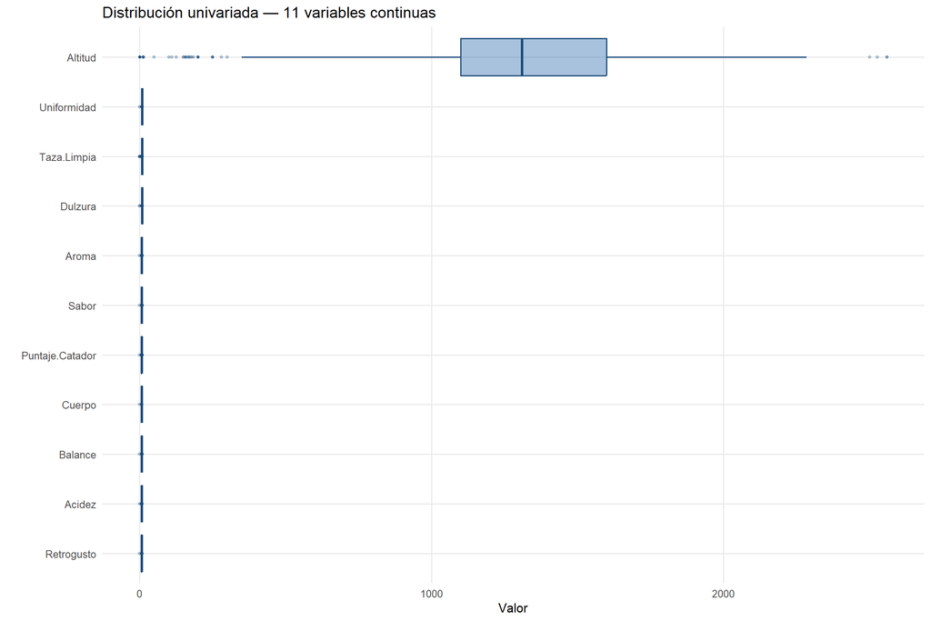

```r
library(tidyr)

datos[, vars_continuas] %>%
  pivot_longer(everything(), names_to="Variable", values_to="Valor") %>%
  ggplot(aes(x=reorder(Variable, Valor, median), y=Valor)) +
  geom_boxplot(fill="#2563a8", alpha=0.4, outlier.alpha=0.3,
               outlier.size=1, color="#1a4a7a") +
  coord_flip() +
  labs(title="Distribución univariada — 11 variables continuas",
       x="", y="Valor") +
  theme_minimal(base_size=12) +
  theme(panel.grid.minor=element_blank())
```

## 3.2. Matriz de dispersión (pares)

La matriz de pares se construye con las primeras seis variables del conjunto de 11. La diagonal muestra distribuciones, el triángulo inferior muestra nubes de puntos y el superior resume correlaciones. Es una vista parcial para facilitar la lectura, no una matriz gráfica de las 11 variables completas.

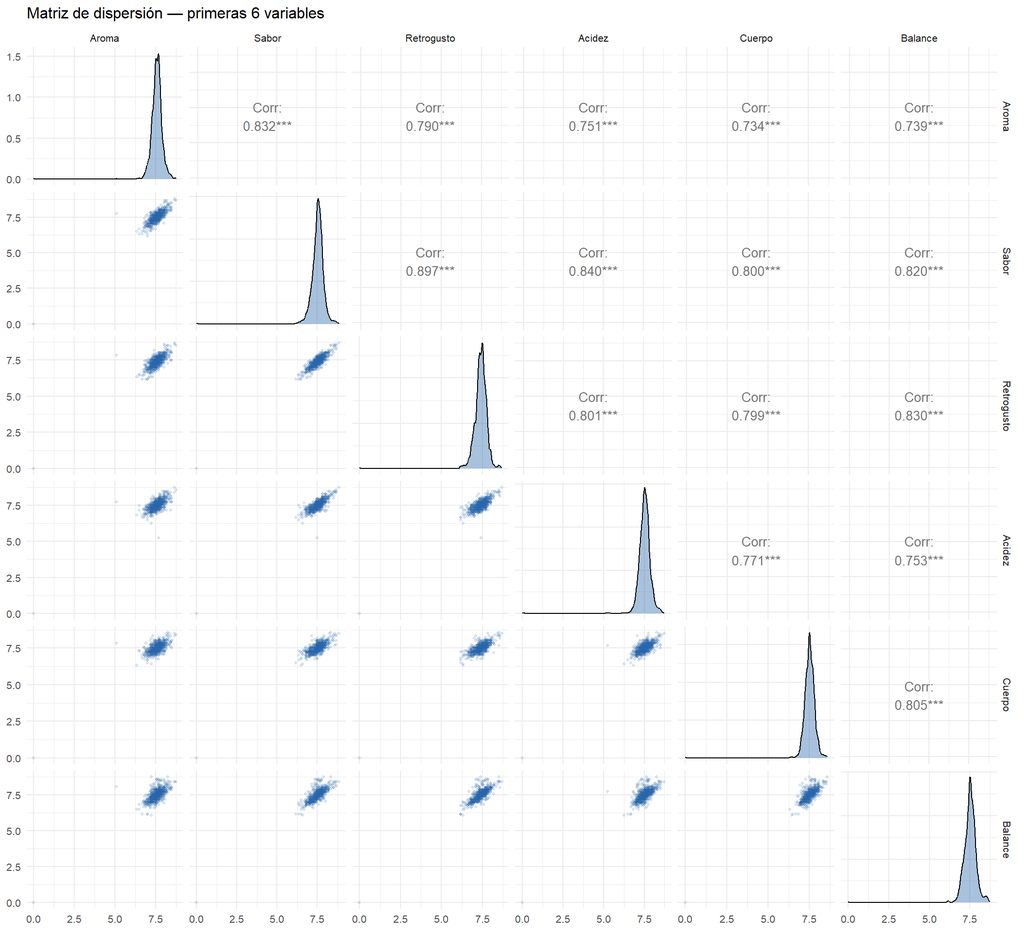

```r
ggpairs(datos[, vars_continuas[1:6]],
        lower=list(continuous=wrap("points", alpha=0.15, size=0.8, color="#2563a8")),
        diag =list(continuous=wrap("densityDiag", fill="#2563a8", alpha=0.4)),
        upper=list(continuous=wrap("cor", size=3.5)),
        title="Matriz de dispersión — primeras 6 variables") +
  theme_minimal(base_size=10)
```

**Cómo se lee.** Las nubes de puntos de los pares muestran la asociación lineal entre variables (más estrecha cuanto mayor la correlación) y las densidades de la diagonal muestran la forma de cada variable. Los números del triángulo superior son las correlaciones de la sección 2.3.

# 4. Distancias multivariadas

Esta sección ilustra dos formas de medir separación: la distancia euclídea sobre variables estandarizadas y la distancia de Mahalanobis, que incorpora la estructura de covarianza entre variables.

## 4.1. Distancia euclídea

```r
datos_std <- scale(datos[, vars_continuas])

# Matriz de distancias euclídeas sobre muestra de 10 lotes
set.seed(42)
idx <- sample(nrow(datos_std), 10)
D_euc <- dist(datos_std[idx, ], method="euclidean")
round(as.matrix(D_euc), 2)
```

```
##       1    2    3    4    5    6    7    8    9   10
## 1  0.00 1.66 1.16 3.25 4.11 2.41 1.86 1.75 1.62 2.67
## 2  1.66 0.00 1.96 2.25 3.16 1.47 1.40 1.50 1.60 3.07
## 3  1.16 1.96 0.00 3.61 4.51 2.37 2.54 1.88 1.97 2.52
## 4  3.25 2.25 3.61 0.00 1.37 2.79 1.69 3.35 2.83 5.05
## 5  4.11 3.16 4.51 1.37 0.00 3.57 2.33 4.24 3.57 5.95
## 6  2.41 1.47 2.37 2.79 3.57 0.00 2.24 1.44 1.41 2.68
## 7  1.86 1.40 2.54 1.69 2.33 2.24 0.00 2.33 1.78 3.91
## 8  1.75 1.50 1.88 3.35 4.24 1.44 2.33 0.00 1.59 1.85
## 9  1.62 1.60 1.97 2.83 3.57 1.41 1.78 1.59 0.00 2.74
## 10 2.67 3.07 2.52 5.05 5.95 2.68 3.91 1.85 2.74 0.00
```

## 4.2. Distancia de Mahalanobis

La distancia de Mahalanobis tiene en cuenta la covarianza entre las 11 variables. El código compara el cuadrado de la distancia con el cuantil 97,5 % de una distribución chi-cuadrado con 11 grados de libertad. Los registros que superan ese umbral se marcan como candidatos atípicos bajo este criterio.

Este es un diagnóstico exploratorio aplicado a la matriz del EDA; no es por sí mismo la regla de selección utilizada para construir la matriz final del PCA. Un lote con $d^2_M > \chi^2_{p,0.975}$ se considera multivariadamente atípico.

```r
dm2 <- mahalanobis(datos[, vars_continuas],
                   colMeans(datos[, vars_continuas]),
                   cov(datos[, vars_continuas]))

umbral <- qchisq(0.975, df=length(vars_continuas))
n_atipicos <- sum(dm2 > umbral)

cat("Umbral chi² al 97.5% (p=11):", round(umbral, 2), "\n")
```

```
## Umbral chi² al 97.5% (p=11): 21.92
```

```r
cat("Lotes atípicos multivariados:", n_atipicos,
    sprintf("(%.1f%%)\n", n_atipicos/nrow(datos)*100))
```

```
## Lotes atípicos multivariados: 85 (7.9%)
```

```r
cat("\nTop 5 distancias de Mahalanobis:\n")
```

```
##
## Top 5 distancias de Mahalanobis:
```

```r
print(sort(dm2, decreasing=TRUE)[1:5])
```

```
## [1] 645.7260 408.2974 248.0021 183.4122 153.8899
```

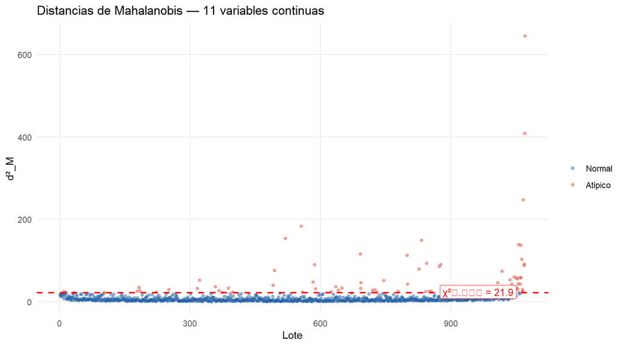

```r
data.frame(id=seq_along(dm2), dm2=dm2) %>%
  ggplot(aes(x=id, y=dm2)) +
  geom_point(aes(color=dm2>umbral), alpha=0.5, size=1.2) +
  geom_hline(yintercept=umbral, linetype="dashed", color="red", linewidth=0.8) +
  scale_color_manual(values=c("TRUE"="#e74c3c","FALSE"="#2563a8"),
                     labels=c("TRUE"="Atípico","FALSE"="Normal"),
                     name="") +
  annotate("label", x=1050, y=umbral*1.1, label=paste0("χ²₀.₉₇₅ = ",round(umbral,1)),
           color="red", size=3.5, hjust=1) +
  labs(title="Distancias de Mahalanobis — 11 variables continuas",
       x="Lote", y="d²_M") +
  theme_minimal() + theme(panel.grid.minor=element_blank())
```

**Cómo se lee.** Con 11 variables el umbral es 21,92 y se marcan 85 lotes (7,9 %). Esta cifra **no es la del PCA final**: allí se usan 8 variables (umbral 17,53) y se retiran 100 lotes de 1.070. Los puntos rojos por encima de la línea punteada son los candidatos a atípicos; los que están muy por encima del umbral son combinaciones de puntajes realmente extrañas.

## 4.3. Comparación de distancias

El código compara la norma euclídea de cada fila estandarizada respecto al origen con la raíz de la distancia de Mahalanobis. **No calcula aquí todas las distancias euclídeas entre pares de lotes**: la matriz de distancias por pares se ilustra con la muestra de 10 observaciones de la subsección 4.1.

La correlación entre ambas medidas resume cuánto se parecen esos dos criterios radiales en esta base.

```r
# Distancia estandarizada (euclídea sobre datos escalados) vs Mahalanobis
d_std <- sqrt(rowSums(datos_std^2))   # euclídea en espacio estandarizado

cat("Correlación euclídea-estandarizada vs Mahalanobis:",
    round(cor(d_std, sqrt(dm2)), 4), "\n")
```

```
## Correlación euclídea-estandarizada vs Mahalanobis: 0.7958
```

```r
cat("(Si correlación < 1: Mahalanobis detecta estructura de covarianza adicional)\n")
```

```
## (Si correlación < 1: Mahalanobis detecta estructura de covarianza adicional)
```

**Cómo se lee.** La correlación entre ambas distancias es 0,80. Con ese valor, las dos ordenan de forma parecida, pero no idéntica, a los lotes más alejados del centro; la diferencia es la estructura de covarianza que solo Mahalanobis incorpora (un lote puede ser raro por una combinación de variables aunque cada una sea normal por separado).

# Conclusiones

1. **Escalas distintas:** la altitud domina la varianza total; antes de cualquier análisis multivariado hay que estandarizar.
2. **Redundancia:** los siete puntajes sensoriales están fuertemente correlacionados entre sí, lo que justifica resumirlos con pocas dimensiones.
3. **Asimetría y extremos:** la mayoría de los lotes puntúa alto y unos pocos quedan muy por debajo; esos lotes generan los «atípicos» del boxplot clásico.
4. **Atípicos multivariados:** la distancia de Mahalanobis marca 85 lotes con las 11 variables; es solo un diagnóstico del EDA. La depuración que se usa en el PCA está en depuración.

# Anexo: EDA complementario de las 14 variables cuantitativas

Este anexo amplía la exploración visual a las 14 variables originales. No reemplaza ni modifica los cálculos principales, que se hicieron sobre 11 variables.

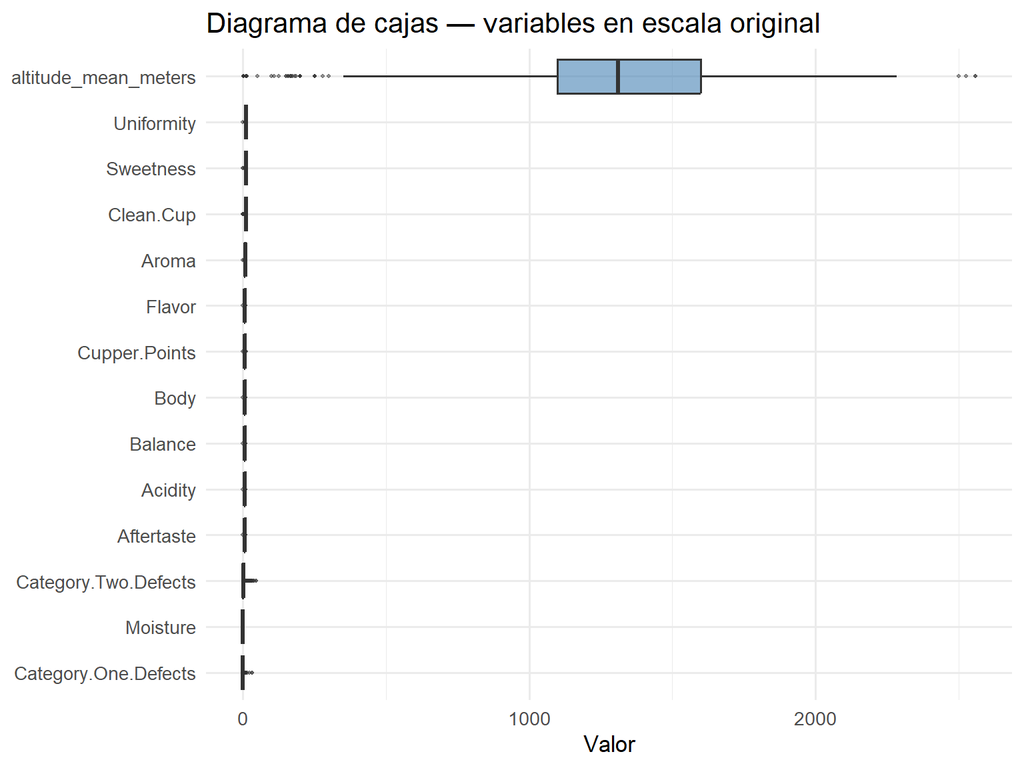

```r
# EDA — Coffee Quality Institute
# Exploración inicial de las 14 variables cuantitativas
# Complemento visual al informe del taller (informe_taller_pca.Rmd)

library(dplyr)
library(ggplot2)
library(tidyr)

# ── Datos ────────────────────────────────────────────────────────────────────

data <- read.csv("../data/arabica_data_cleaned.csv")

vars_cuantitativas <- c("Aroma", "Flavor", "Aftertaste", "Acidity", "Body",
                        "Balance", "Uniformity", "Clean.Cup", "Sweetness",
                        "Cupper.Points", "Moisture", "Category.One.Defects",
                        "Category.Two.Defects", "altitude_mean_meters")

data_f <- data %>%
  filter(is.na(altitude_mean_meters) |
           (altitude_mean_meters > 0 & altitude_mean_meters <= 3000)) %>%
  filter(!is.na(altitude_mean_meters))

datos <- data_f %>% select(all_of(vars_cuantitativas))

# ── 1. Diagrama de cajas — todas las variables en escala original ─────────────
# Muestra diferencias de escala: altitude_mean_meters domina el rango.

datos_long <- datos %>%
  pivot_longer(everything(), names_to = "variable", values_to = "valor")

ggplot(datos_long, aes(x = reorder(variable, valor, FUN = median), y = valor)) +
  geom_boxplot(fill = "steelblue", alpha = 0.6, outlier.size = 0.8,
               outlier.alpha = 0.5) +
  coord_flip() +
  labs(title = "Diagrama de cajas — variables en escala original",
       x = NULL, y = "Valor") +
  theme_minimal(base_size = 13)
```

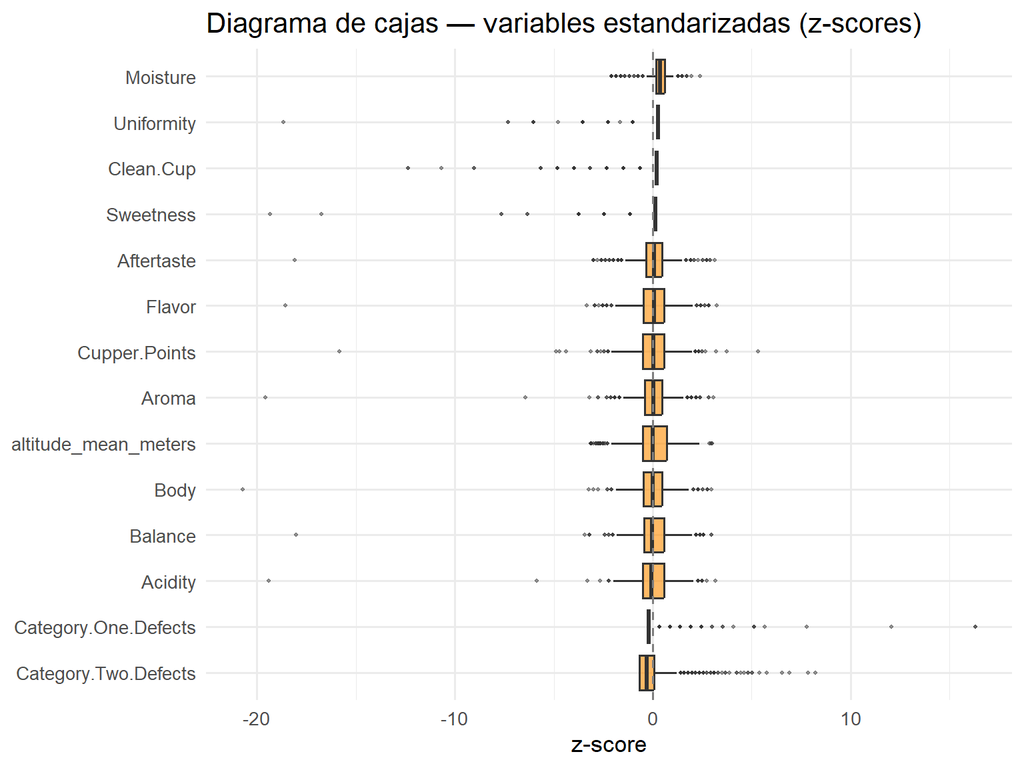

```r
# ── 2. Diagrama de cajas — variables estandarizadas ──────────────────────────
# Permite comparar dispersión entre variables en la misma escala (z-scores).
# Outliers visibles en todas las variables a la vez.

datos_z <- as.data.frame(scale(datos))

datos_z_long <- datos_z %>%
  pivot_longer(everything(), names_to = "variable", values_to = "z")

ggplot(datos_z_long, aes(x = reorder(variable, z, FUN = median), y = z)) +
  geom_boxplot(fill = "darkorange", alpha = 0.6, outlier.size = 0.8,
               outlier.alpha = 0.5) +
  geom_hline(yintercept = 0, linetype = "dashed", color = "gray50") +
  coord_flip() +
  labs(title = "Diagrama de cajas — variables estandarizadas (z-scores)",
       x = NULL, y = "z-score") +
  theme_minimal(base_size = 13)
```

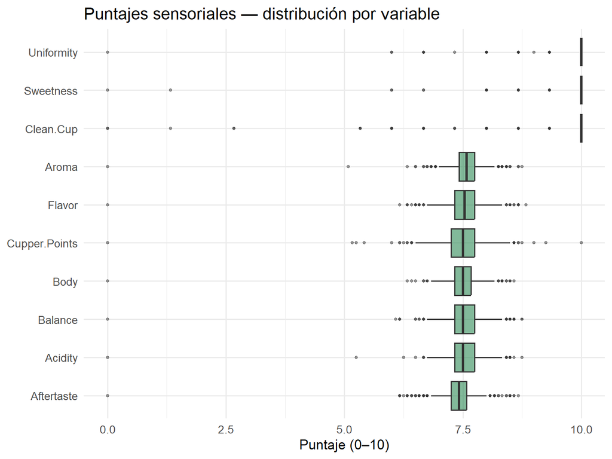

```r
# ── 3. Cajas solo para los puntajes sensoriales ───────────────────────────────
# Revela la asimetría izquierda: la mayoría de lotes puntúa alto (7–8.5),
# con unos pocos outliers bajos — en particular el lote con todo en cero.

vars_sensoriales <- c("Aroma", "Flavor", "Aftertaste", "Acidity", "Body",
                      "Balance", "Uniformity", "Clean.Cup", "Sweetness",
                      "Cupper.Points")

datos %>%
  select(all_of(vars_sensoriales)) %>%
  pivot_longer(everything(), names_to = "variable", values_to = "puntaje") %>%
  ggplot(aes(x = reorder(variable, puntaje, FUN = median), y = puntaje)) +
  geom_boxplot(fill = "seagreen", alpha = 0.6, outlier.size = 1,
               outlier.alpha = 0.5) +
  coord_flip() +
  labs(title = "Puntajes sensoriales — distribución por variable",
       x = NULL, y = "Puntaje (0–10)") +
  theme_minimal(base_size = 13)
```

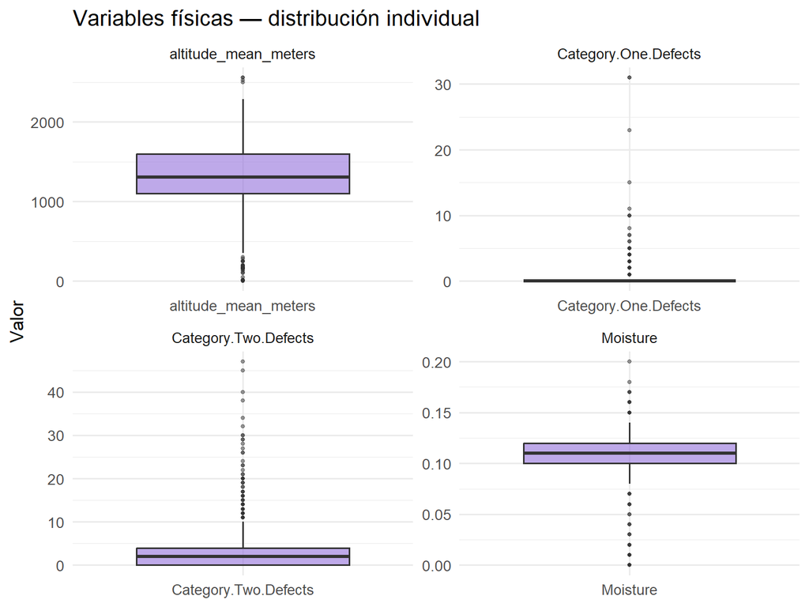

```r
# ── 4. Cajas para variables físicas ───────────────────────────────────────────
# Moisture, defectos y altitud: escalas completamente distintas entre sí.

vars_fisicas <- c("Moisture", "Category.One.Defects",
                  "Category.Two.Defects", "altitude_mean_meters")

datos %>%
  select(all_of(vars_fisicas)) %>%
  pivot_longer(everything(), names_to = "variable", values_to = "valor") %>%
  ggplot(aes(x = variable, y = valor)) +
  geom_boxplot(fill = "mediumpurple", alpha = 0.6, outlier.size = 1,
               outlier.alpha = 0.5) +
  facet_wrap(~variable, scales = "free") +
  labs(title = "Variables físicas — distribución individual",
       x = NULL, y = "Valor") +
  theme_minimal(base_size = 13)
```

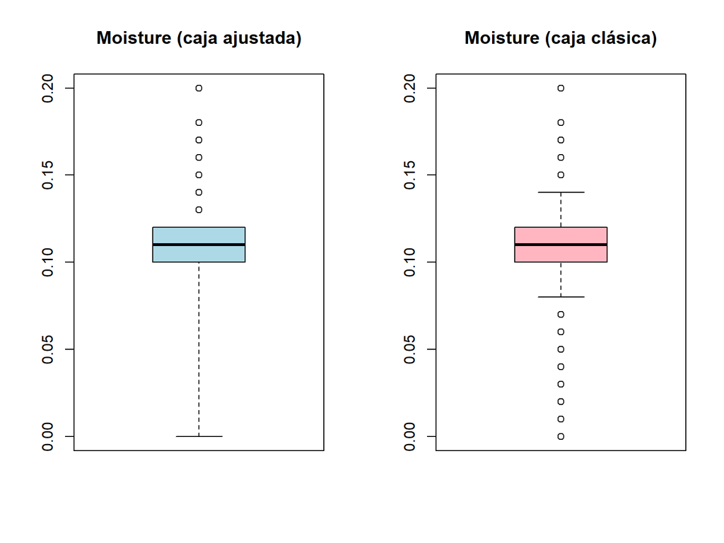

```r
# ── 5. Cajas ajustadas (robustas a asimetría) vs. clásicas ────────────────────
# La regla clásica de Tukey (1.5*RIC a ambos lados) sobre-marca atípicos en
# variables sesgadas. adjbox() (Hubert & Vandervieren) ajusta los bigotes con el
# medcouple: Moisture pasa de 222 a 114 atípicos y Category.Two.Defects de 77 a 20.

library(robustbase)

par(mfrow = c(1, 2))
adjbox(datos$Moisture, main = "Moisture (caja ajustada)", col = "lightblue")
boxplot(datos$Moisture, main = "Moisture (caja clásica)", col = "lightpink")
```

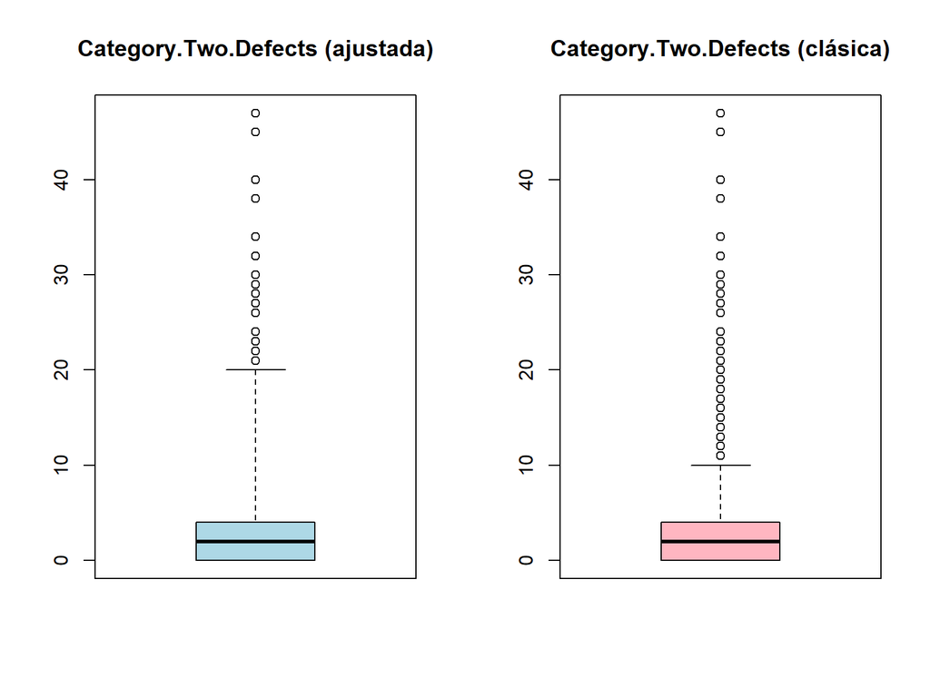

```r
adjbox(datos$Category.Two.Defects, main = "Category.Two.Defects (ajustada)", col = "lightblue")
boxplot(datos$Category.Two.Defects, main = "Category.Two.Defects (clásica)", col = "lightpink")
```

```r
par(mfrow = c(1, 1))
```